# Evaluating Car Crash Incidents in Philadelphia

BMIN5030 Final Project

Author

Tanis Dorwart

# 1 Overview

This project seeks to analyze and highlight specific factors and areas within Philadelphia where car accidents are prevalent and suggests strategies to improve traffic safety in these regions. Data used to produce this analysis was sourced from OpenDataPhilly, using their [Crash Data 2020-2024](https://opendataphilly.org/datasets/crashes/) dataset. City limit boundaries which are utilized for the geospatial maps were obtained from [here](https://opendataphilly.org/datasets/city-limits/).

Follow the link [here](https://github.com/tanisdorwart/final-project) to access the GitHub repository.

# 2 Introduction

Over the last five years, over 36,000 car accidents have occurred in and around Philadelphia. While the annual number of crashes is decreasing, additional steps to increase the safety of drivers, pedestrians, and passengers can be improved upon. Of those 36,000 car crashes, over 600 lives were lost due to these accidents. In this analysis I will investigate the trends in road safety over the last five years and identify specific factors which influence the likelihood of accidents occurring in Philadelphia.

Philadelphia is a very diverse, highly trafficked city. This city is home to 1.5 million people, 46.7% of which commute to and from work via cars by themselves ([source](https://worldpopulationreview.com/us-cities/pennsylvania/philadelphia), [source](https://datausa.io/profile/geo/philadelphia-pa/)). This high rate of cars on the road increases traffic volume and is suspected to lead to more accidents.

I sought to find out if there were particular trends regarding factors such as time of day or weather which make accidents more likely. Additionally, by plotting where these accidents occur, I can identify areas of Philadelphia which need enhanced safety precautions to decrease the frequency of accidents and offer strategies to increase road safety for Philadelphia residents.

# 3 Methods

Data used for this analysis was obtained from [OpenDataPhilly](https://opendataphilly.org/), a publicly available and accessible repository containing a wide range of data for the city of Philadelphia. The repository contains data of accidents in Philadelphia dating back to 2007, for the purpose of this analysis, accidents which occurred from 2020-2024 were selected. This website will also be the source of our shapefiles and neighborhood boundaries when generating our geospatial maps of this dataset.

## 3.1 R Libraries

```r
# Load packages

library("tidyverse")
library("ggplot2")
library("RColorBrewer")
library("dplyr")
library("stringr")
library("readr")
library("tidymodels")
library("dotwhisker")
library("broom")
library("RColorBrewer")
library("paletteer")
library("maps")
library("sf")
library("osmdata")
library("lwgeom")
library("ggspatial")
library("leaflet")
library("leafletCN")
```

## 3.2 Cleaning Data, Extracting Values of Interest

```r
# After downloading the "collision_crash_2020_2024.csv" file from OpenDataPhilly, read in the dataset
crash_data <- read.csv("collision_crash_2020_2024.csv")

# ----- Clean data -----
# Select variables of interest for this analysis
crash_clean <- crash_data %>%
  select(
    automobile_count,
    bicycle,
    bicycle_count,
    crash_month,
    crash_year,
    day_of_week,
    fatal,
    fatal_count,
    hour_of_day,
    motorcycle_count,
    pedestrian,
    susp_minor_inj_count,
    susp_serious_inj_count,
    time_of_day,
    total_units,
    unbelted_occ_count,
    unb_death_count,
    unb_susp_serious_inj_count,
    unbelted,
    vehicle_count,
    weather1,
    weather2,
    alcohol_related,
    cell_phone,
    distracted,
    drugged_driver,
    drug_related,
    impaired_driver,
    municipality,
    county,
    dec_longitude,
    dec_latitude)

# Rename variables with characters instead of numeric values
# Numeric value code descriptions were obtained from the "PennDOT Open Data Portal Crash Data Dictionary and Field Constraints Table" from OpenDataPhilly
crash_clean <- mutate(crash_clean, crash_month = factor(crash_month, levels = c(1:12),
                    labels = c("January", "February", "March", "April", "May", "June", "July", "August", "September", "October", "November", "December")))

crash_clean <- mutate(crash_clean, day_of_week = factor(day_of_week, levels = c(1:7),
                                                        labels = c("Sunday", "Monday", "Tuesday", "Wednesday", "Thursday", "Friday", "Saturday")))

crash_clean <- crash_clean %>%
  slice(-8108)

crash_clean <- mutate(crash_clean, hour_of_day_12 = factor(hour_of_day, levels = c(0:23),
                                                        labels = c("12 AM", "1 AM", "2 AM", "3 AM", "4 AM", "5 AM", "6 AM", "7 AM", "8 AM", "9 AM", "10 AM", "11 AM", "12 PM", "1 PM", "2 PM", "3 PM", "4 PM", "5 PM", "6 PM", "7 PM", "8 PM", "9 PM", "10 PM", "11 PM")))

crash_clean <- mutate(crash_clean, weather1 = factor(weather1, levels = c(1:7),
                                                     labels = c("Blowing Sand, Soil, Dirt", "Blowing Snow", "Clear", "Cloudy", "Fog, Smog, Smoke", "Freezing Rain or Freezing Drizzle", "Rain")))


crash_clean <- mutate(crash_clean, weather2 = factor(weather2, levels = c(1:10, 98),
                                                     labels = c("Blowing Sand, Soil, Dirt", "Blowing Snow", "Clear", "Cloudy", "Fog, Smog, Smoke", "Freezing Rain or Freezing Drizzle", "Rain", "Severe Crosswinds", "Sleet or Hail", "Snow", "Other")))

crash_clean$fatal <- factor(crash_clean$fatal,
                             levels = c(0, 1),
                             labels = c("No", "Yes"))

crash_clean$municipality <- factor(crash_clean$municipality)

crash_clean$crash_year <- as.factor(crash_clean$crash_year)
```

# 4 Results

## 4.1 Observing General Trends in Car Accidents

Over the last five years, the overall number of car crashes is trending downward. However, the number of fatalities as a result of these accidents has not decreased at the same rate and remains relatively unchanged.

```r
# How many accidents occurred each year from 2020-2024 in Philadelphia?
count(crash_clean, crash_year)
```

```
  crash_year    n
1       2020 8109
2       2021 8458
3       2022 6911
4       2023 6904
5       2024 5920
```

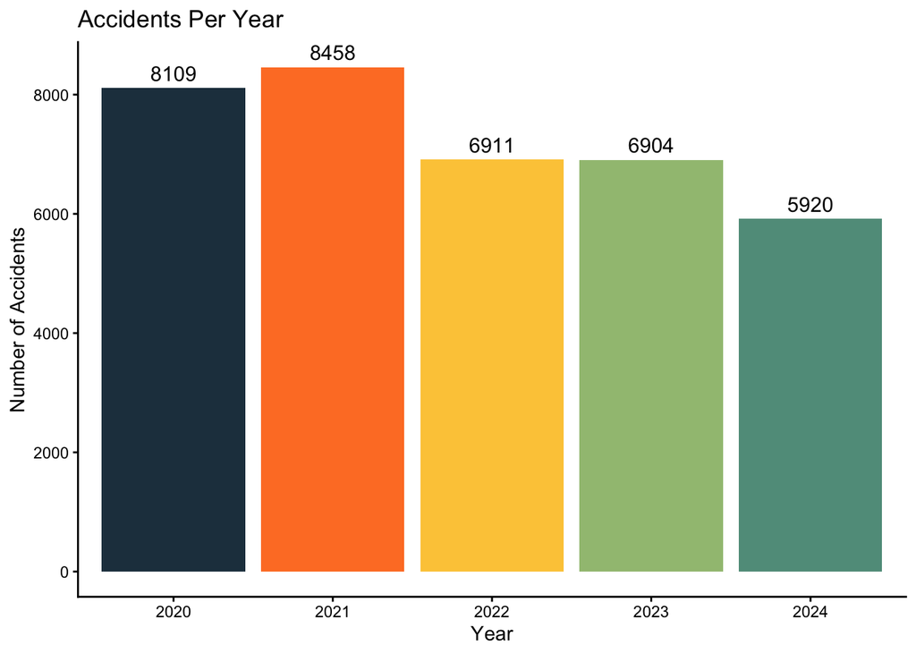

```r
# Create a barplot of the number of accidents for each year
ggplot(data = crash_clean, aes(x = crash_year, fill = crash_year)) +
  geom_bar(position = "stack", stat = "count", show.legend = FALSE) +
  labs(title = "Accidents Per Year",
       x = "Year",
       y = "Number of Accidents",
       fill = "Year") +
  theme_classic() +
  scale_fill_manual(values = c("2020" = "#233d4d",
                               "2021" = "#fe7f2d",
                               "2022" = "#fcca46",
                               "2023" = "#a1c181",
                               "2024" = "#619b8a")) +
  geom_text(
    stat = "count",
    aes(label = after_stat(count)),
    vjust = -0.5,
    size = 4)
```

```r
# How many accidents resulted in fatalities for each year?
crash_clean %>%
  group_by(crash_year) %>%
  count(fatal_count>0)
```

```
# A tibble: 10 × 3
# Groups:   crash_year [5]
   crash_year `fatal_count > 0`     n
   <fct>      <lgl>             <int>
 1 2020       FALSE              7966
 2 2020       TRUE                143
 3 2021       FALSE              8340
 4 2021       TRUE                118
 5 2022       FALSE              6791
 6 2022       TRUE                120
 7 2023       FALSE              6784
 8 2023       TRUE                120
 9 2024       FALSE              5801
10 2024       TRUE                119
```

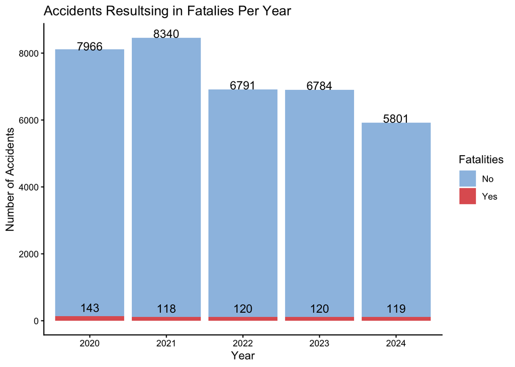

```r
# Remake the barlpot to show how many accidents had a fatality for each year
ggplot(data = crash_clean, aes(x = crash_year, fill = fatal)) +
  geom_bar(position = "stack", stat = "count") +
  labs(title = "Accidents Resultsing in Fatalies Per Year",
       x = "Year",
       y = "Number of Accidents",
       fill = "Fatalities") +
  theme_classic() +
  scale_fill_manual(values = c("No" = "#9DC0E3",
                               "Yes" = "#E06060")) +
  geom_text(stat = "count", # Adds total counts for each group (fatal/not fatal) to the bar plot
    aes(label = after_stat(count)),
    vjust = -0.5,
    size = 4)
```

## 4.2 Factors Influencing Crash Rate

Is there a particular time of the year, day of the week, hour of the day, or type of weather which influences the likelihood of an accident occurring. Plots were generated to visualize how each of the previously mentioned factors may increase or decrease the potential of an accident.

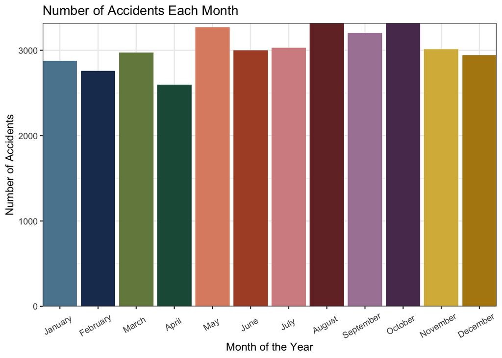

```r
# Which month has the most automobile accidents
ggplot(crash_clean, aes(x = crash_month, fill = crash_month)) +
  geom_bar(show.legend = FALSE) +
  theme_bw() +
  scale_fill_paletteer_d("MetBrewer::Redon") +
  labs(title = "Number of Accidents Each Month",
    x = "Month of the Year",
    y = "Number of Accidents",
    fill = "Month") +
  scale_x_discrete(expand = c(0, 0)) +
  scale_y_continuous(expand = c(0, 0)) +
  theme(axis.text.x = element_text(angle = 30, vjust = .6, hjust = 0.6))
```

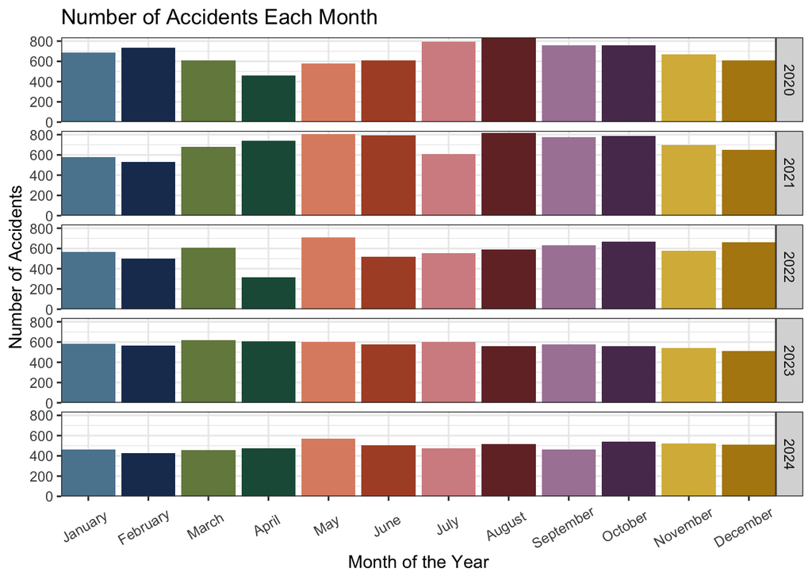

```r
# In which month did the most crashes occur, filtered by year?
ggplot(crash_clean, aes(x = crash_month, fill = crash_month)) +
  geom_bar(show.legend = FALSE) +
  facet_grid(rows =  vars(crash_year)) + # Seperates the data into graphs grouped by year and counted by number of accidents per month per year
  theme_bw() +
  scale_fill_paletteer_d("MetBrewer::Redon") +
  labs(title = "Number of Accidents Each Month",
    x = "Month of the Year",
    y = "Number of Accidents",
    fill = "Month") +
  scale_x_discrete(expand = c(0, 0)) +
  scale_y_continuous(expand = c(0, 0)) +
  theme(axis.text.x = element_text(angle = 30, vjust = .6, hjust = 0.6))
```

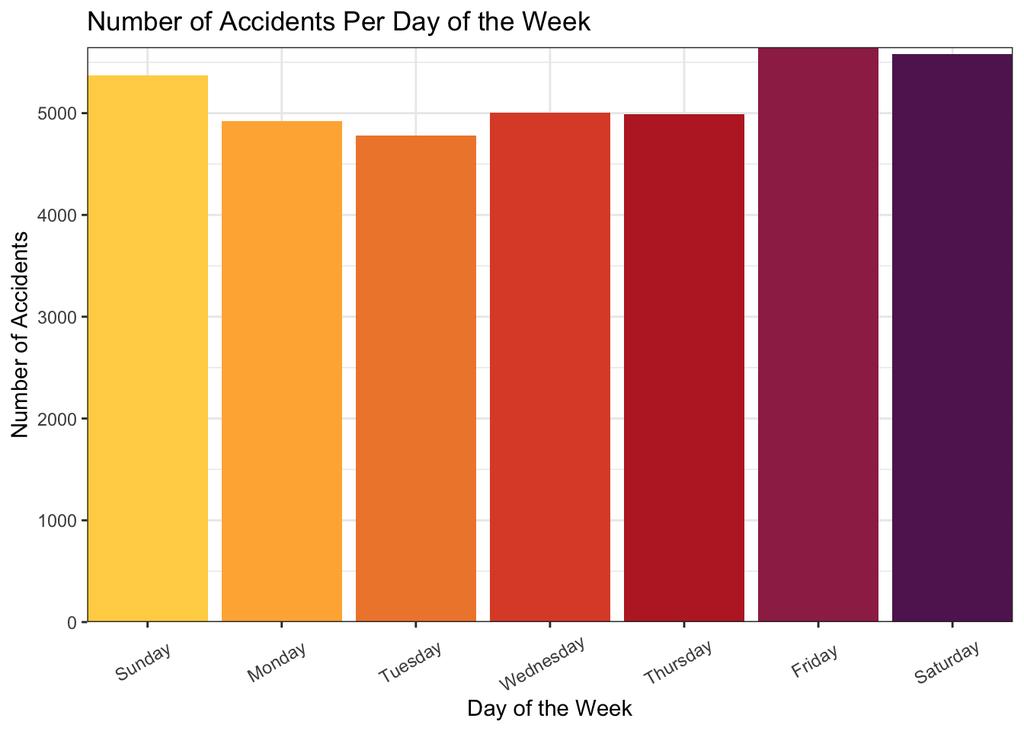

```r
# Which day of the week did the most crashes occur?
ggplot(crash_clean, aes(x = day_of_week, fill = day_of_week)) +
  geom_bar(show.legend = FALSE) +
  theme_bw() +
  scale_fill_paletteer_d("MetBrewer::Tam") +
  labs(title = "Number of Accidents Per Day of the Week",
       x = "Day of the Week",
       y = "Number of Accidents",
       fill = "Day of the Week") +
  scale_x_discrete(expand = c(0, 0)) +
  scale_y_continuous(expand = c(0, 0)) +
  theme(axis.text.x = element_text(angle = 30, vjust = .6, hjust = 0.6))
```

August, October, and May have the highest number of accidents when looking at all accidents from 2020-2024. Interestingly, when filtered by year, new trends can be observed. For example, August only appears to remain the top month with the most accidents for years 2020 and 2021. Additionally, when examining the two most recent years of the report, the number of accidents by month is less variable and appears more uniform than the previous three years. Another observation of note is that the frequency of accidents decreased in April of 2020 following the announcement of COVID quarantine procedures and suggestions to remain home during the pandemic.

Another interesting observation noted is that Friday is the day of the week when the most car accidents occur. This led me to ask: “Is an accident statistically more likely to occur on Friday compared to any other day of the week?”.

```r
# Summarize the number of accidents which occured each day of the week into a new df
crash_days <- crash_clean |>
  filter(day_of_week %in% c("Monday", "Tuesday", "Wednesday", "Thursday", "Friday", "Saturday", "Sunday")) |>
  count(day_of_week)

#Monday vs Friday
prop.test(
  x = c(crash_days$n[crash_days$day_of_week == "Friday"], crash_days$n[crash_days$day_of_week == "Monday"]),
  n = c(nrow(crash_clean), nrow(crash_clean)),
  alternative = "greater")
```

```
    2-sample test for equality of proportions with continuity correction

data:  c(crash_days$n[crash_days$day_of_week == "Friday"], crash_days$n[crash_days$day_of_week == "Monday"]) out of c(nrow(crash_clean), nrow(crash_clean))
X-squared = 57.862, df = 1, p-value = 1.406e-14
alternative hypothesis: greater
95 percent confidence interval:
 0.01561136 1.00000000
sample estimates:
   prop 1    prop 2
0.1556113 0.1356675
```

```r
#Tuesday vs Friday
prop.test(
  x = c(crash_days$n[crash_days$day_of_week == "Friday"], crash_days$n[crash_days$day_of_week == "Tuesday"]),
  n = c(nrow(crash_clean), nrow(crash_clean)),
  alternative = "greater")
```

```
    2-sample test for equality of proportions with continuity correction

data:  c(crash_days$n[crash_days$day_of_week == "Friday"], crash_days$n[crash_days$day_of_week == "Tuesday"]) out of c(nrow(crash_clean), nrow(crash_clean))
X-squared = 84.16, df = 1, p-value < 2.2e-16
alternative hypothesis: greater
95 percent confidence interval:
 0.01960331 1.00000000
sample estimates:
   prop 1    prop 2
0.1556113 0.1317007
```

```r
#Wednesday vs Friday
prop.test(
  x = c(crash_days$n[crash_days$day_of_week == "Friday"], crash_days$n[crash_days$day_of_week == "Wednesday"]),
  n = c(nrow(crash_clean), nrow(crash_clean)),
  alternative = "greater")
```

```
    2-sample test for equality of proportions with continuity correction

data:  c(crash_days$n[crash_days$day_of_week == "Friday"], crash_days$n[crash_days$day_of_week == "Wednesday"]) out of c(nrow(crash_clean), nrow(crash_clean))
X-squared = 45.191, df = 1, p-value = 8.935e-12
alternative hypothesis: greater
95 percent confidence interval:
 0.01333835 1.00000000
sample estimates:
   prop 1    prop 2
0.1556113 0.1379263
```

```r
#Thursday vs Friday
prop.test(
  x = c(crash_days$n[crash_days$day_of_week == "Friday"], crash_days$n[crash_days$day_of_week == "Thursday"]),
  n = c(nrow(crash_clean), nrow(crash_clean)),
  alternative = "greater")
```

```
    2-sample test for equality of proportions with continuity correction

data:  c(crash_days$n[crash_days$day_of_week == "Friday"], crash_days$n[crash_days$day_of_week == "Thursday"]) out of c(nrow(crash_clean), nrow(crash_clean))
X-squared = 47.832, df = 1, p-value = 2.322e-12
alternative hypothesis: greater
95 percent confidence interval:
 0.01383729 1.00000000
sample estimates:
   prop 1    prop 2
0.1556113 0.1374304
```

```r
#Saturday vs Friday
prop.test(
  x = c(crash_days$n[crash_days$day_of_week == "Friday"], crash_days$n[crash_days$day_of_week == "Saturday"]),
  n = c(nrow(crash_clean), nrow(crash_clean)),
  alternative = "greater")
```

```
    2-sample test for equality of proportions with continuity correction

data:  c(crash_days$n[crash_days$day_of_week == "Friday"], crash_days$n[crash_days$day_of_week == "Saturday"]) out of c(nrow(crash_clean), nrow(crash_clean))
X-squared = 0.5016, df = 1, p-value = 0.2394
alternative hypothesis: greater
95 percent confidence interval:
 -0.002513614  1.000000000
sample estimates:
   prop 1    prop 2
0.1556113 0.1536830
```

```r
#Sunday vs Friday
prop.test(
  x = c(crash_days$n[crash_days$day_of_week == "Friday"], crash_days$n[crash_days$day_of_week == "Sunday"]),
  n = c(nrow(crash_clean), nrow(crash_clean)),
  alternative = "greater")
```

```
    2-sample test for equality of proportions with continuity correction

data:  c(crash_days$n[crash_days$day_of_week == "Friday"], crash_days$n[crash_days$day_of_week == "Sunday"]) out of c(nrow(crash_clean), nrow(crash_clean))
X-squared = 8.1489, df = 1, p-value = 0.002154
alternative hypothesis: greater
95 percent confidence interval:
 0.003222295 1.000000000
sample estimates:
   prop 1    prop 2
0.1556113 0.1479808
```

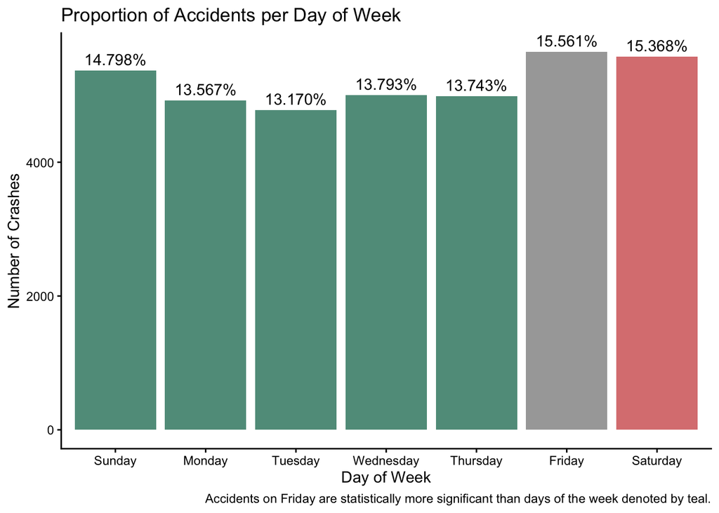

```r
# Create a new column in our crash_days df which shows the proportion (prop) of accidents which occcurred on that day
crash_days <- crash_clean %>%
  count(day_of_week) %>%
  mutate(prop = n / sum(n))

# Replot the proportion of accidents for each day of the week and color bars based on statistical significance compared to accidents which occurred on Friday
ggplot(crash_days, aes(x = day_of_week, y = n, fill = day_of_week)) +
  geom_bar(stat = "identity") +
  scale_fill_manual(values = c("Monday" = "#619b8a", "Tuesday" = "#619b8a", "Wednesday" = "#619b8a", "Thursday" = "#619b8a", "Saturday" = "#DB8181","Sunday" = "#619b8a", "Friday" = "#A8A8A8")) +
  labs(title = "Proportion of Accidents per Day of Week",
       x = "Day of Week",
       y = "Number of Crashes",
       caption = "Accidents on Friday are statistically more significant than days of the week denoted by teal.") +
  geom_text(aes(label = scales::percent(prop)), vjust = -0.5) +
  theme_classic() +
  theme(legend.position = "none")
```

With a p value < 0.005, accidents on Friday are statistically more likely to happen than on a Monday, Tuesday, Wednesday, Thursday, or Sunday (denoted by teal bars on the graph). However, accidents on Friday are not statistically more likely to happen than on a Saturday. I find this interesting as one would expect a higher volume of drivers during the week due to daily commutes to work as opposed to over the weekend for leisure.

## 4.3 Rush Hour & Car Accidents

According to PennDOT spokesperson Brad Rudolph, there are 120,000-200,000 cars on the road every day in Philadelphia ([source](https://www.cbsnews.com/philadelphia/news/philadelphia-traffic-tomtom-traffic-index-2023/)). One would assume that an increased number of vehicles on the road would correlate to an increase in the number of accidents occurring throughout the day. Below are bar graphs and statistics to visualize and determine if accidents are more likely to occur during rush hour (3-6pm) than outside of rush hour.

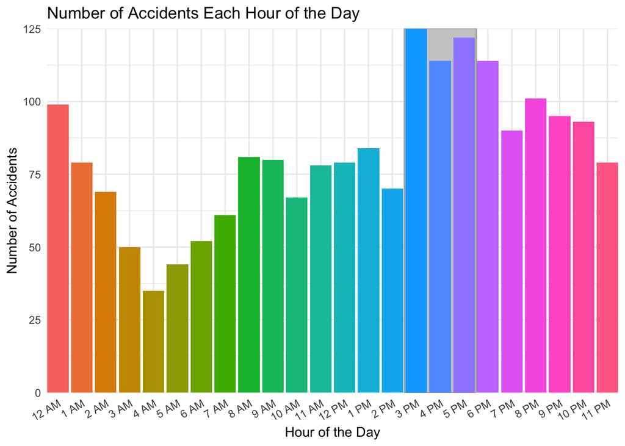

```r
#What time of day are crashes most likely to occur?
crash_clean %>%
  filter(!is.na(hour_of_day_12)) %>% #Remove rows where a time of the accident was not recorded from this analysis
  ggplot(aes(x = hour_of_day_12, fill = hour_of_day_12)) +
  geom_rect(
    aes(xmin = 15.5, xmax = 18.5, ymin = 0, ymax = 125), ## Evening "rush hour": 3-6pm
    color = "gray70",
    fill = "gray80",
    inherit.aes = FALSE) + # Prevents inheriting the original data's aesthetics
  geom_bar(show.legend = FALSE) +
  labs(title = "Number of Accidents Each Hour of the Day",
       x = "Hour of the Day",
       y = "Number of Accidents") +
  scale_x_discrete(expand = c(0, 0)) +
  scale_y_continuous(expand = c(0, 0)) +
  theme_minimal() +
  theme(axis.text.x = element_text(angle = 30, vjust = 1, hjust = 1))
```

```r
# Are accidents statistically more likely to occur during rush hour than any other time of day?
crash_hourly <- crash_clean |>
  filter(!is.na(hour_of_day)) |>   # remove rows where hour_of_day is missing
  mutate(
    rush_hour = ifelse(hour_of_day %in% 15:18, "Rush Hour", "Other Times"),
    rush_hour = factor(rush_hour, levels = c("Other Times", "Rush Hour")))

table(crash_hourly$rush_hour)
```

```
Other Times   Rush Hour
       1486         475
```

```r
prop.table(table(crash_hourly$rush_hour))
```

```
Other Times   Rush Hour
  0.7577766   0.2422234
```

```r
chisq.test(table(crash_hourly$rush_hour))
```

```
    Chi-squared test for given probabilities

data:  table(crash_hourly$rush_hour)
X-squared = 521.22, df = 1, p-value < 2.2e-16
```

```r
rush_model <- glm(rush_hour ~ 1, data = crash_hourly, family = binomial)
summary(rush_model)
```

```
Call:
glm(formula = rush_hour ~ 1, family = binomial, data = crash_hourly)

Coefficients:
            Estimate Std. Error z value Pr(>|z|)
(Intercept) -1.14053    0.05271  -21.64   <2e-16 ***
---
Signif. codes:  0 '***' 0.001 '**' 0.01 '*' 0.05 '.' 0.1 ' ' 1

(Dispersion parameter for binomial family taken to be 1)

    Null deviance: 2171.3  on 1960  degrees of freedom
Residual deviance: 2171.3  on 1960  degrees of freedom
AIC: 2173.3

Number of Fisher Scoring iterations: 4
```

```r
plogis(coef(rush_model))
```

```
(Intercept)
  0.2422234
```

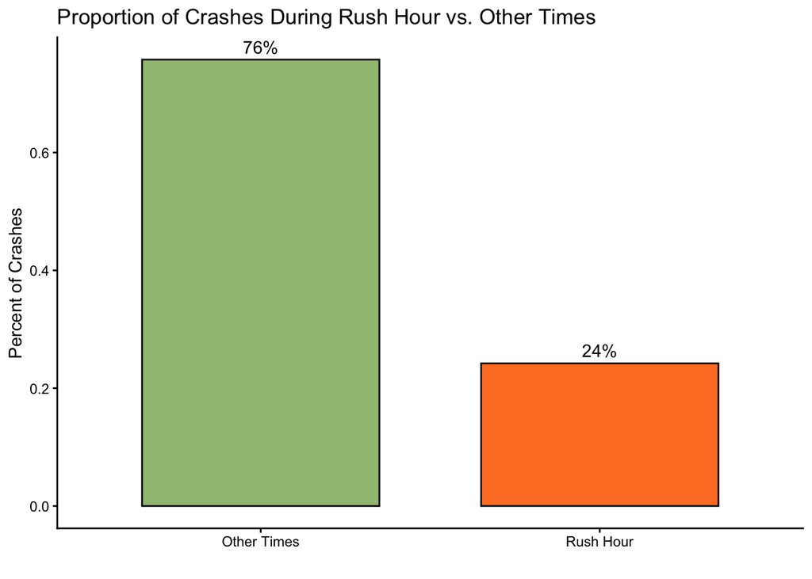

```r
# Graph the proportion of accidents which occurred during rush hour vs. any other time of the day
crash_hourly %>%
  count(rush_hour) %>%
  mutate(prop = n / sum(n)) |>
  ggplot(aes(x = rush_hour, y = prop, fill = rush_hour)) +
  geom_col(color = "black", show.legend = FALSE, width = 0.7) +
  geom_text(aes(label = scales::percent(prop)), vjust = -0.5) +
  scale_fill_manual(values = c("Other Times" = "#A1C181", "Rush Hour" = "#FE7F2D")) +
  theme_classic() +
  guides(fill = guide_legend(title = "Time Frame", reverse = TRUE)) +
  labs(title = "Proportion of Crashes During Rush Hour vs. Other Times",
       x = "",
       y = "Percent of Crashes")
```

```r
# Taking into account that "rush hour" only accounts for 3hrs of the day, we can normalize the nmber of accidents per hour for "rush hour" vs "non rush hour" groups.
rush_summary <- crash_hourly %>%
  count(rush_hour) %>%
  mutate(
    hours_in_group = ifelse(rush_hour == "Rush Hour", 3, 21),
    accidents_per_hour = n / hours_in_group)

rush_summary
```

```
    rush_hour    n hours_in_group accidents_per_hour
1 Other Times 1486             21            70.7619
2   Rush Hour  475              3           158.3333
```

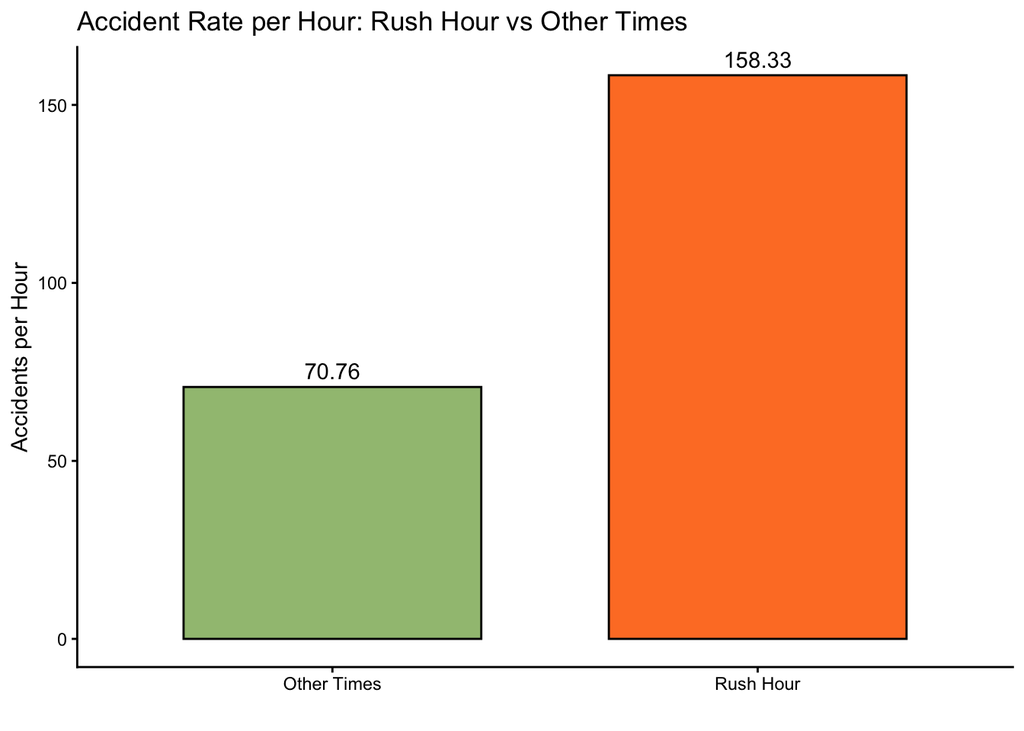

```r
# Graph the rate of accidents per hour
ggplot(rush_summary, aes(x = rush_hour, y = accidents_per_hour, fill = rush_hour)) +
  geom_col(color = "black", show.legend = FALSE, width = 0.7) +
  geom_text(aes(label = round(accidents_per_hour, 2)), vjust = -0.5) +
  labs(
    title = "Accident Rate per Hour: Rush Hour vs Other Times",
    y = "Accidents per Hour",
    x = "") +
  scale_fill_manual(values = c("Other Times" = "#A1C181", "Rush Hour" = "#FE7F2D")) +
  theme_classic() +
  theme(legend.position = "none")
```

```r
# To look for confounding factors:
glm(rush_hour ~ day_of_week + crash_month + fatal,
    data = crash_hourly, family = binomial) |> summary()
```

```
Call:
glm(formula = rush_hour ~ day_of_week + crash_month + fatal,
    family = binomial, data = crash_hourly)

Coefficients:
                     Estimate Std. Error z value Pr(>|z|)
(Intercept)          -1.22319    0.21139  -5.786 7.19e-09 ***
day_of_weekMonday     0.63213    0.20279   3.117 0.001826 **
day_of_weekTuesday    0.47406    0.21510   2.204 0.027535 *
day_of_weekWednesday  0.67283    0.20013   3.362 0.000774 ***
day_of_weekThursday   0.43584    0.21022   2.073 0.038146 *
day_of_weekFriday     0.43738    0.19968   2.190 0.028494 *
day_of_weekSaturday   0.32711    0.20157   1.623 0.104618
crash_monthFebruary  -0.61750    0.20572  -3.002 0.002685 **
crash_monthMarch     -0.37326    0.20886  -1.787 0.073914 .
crash_monthApril     -0.57388    0.22715  -2.526 0.011521 *
crash_monthMay       -0.49226    0.25836  -1.905 0.056734 .
crash_monthJune      -0.38537    0.38371  -1.004 0.315212
crash_monthJuly      -0.06535    0.55938  -0.117 0.907001
crash_monthAugust    -0.03427    0.23744  -0.144 0.885222
crash_monthSeptember -0.01968    0.22646  -0.087 0.930738
crash_monthOctober   -0.04930    0.39577  -0.125 0.900861
crash_monthNovember  -0.12119    0.31290  -0.387 0.698522
crash_monthDecember  -0.32142    0.27008  -1.190 0.234019
fatalYes             -0.68820    0.41497  -1.658 0.097232 .
---
Signif. codes:  0 '***' 0.001 '**' 0.01 '*' 0.05 '.' 0.1 ' ' 1

(Dispersion parameter for binomial family taken to be 1)

    Null deviance: 2171.3  on 1960  degrees of freedom
Residual deviance: 2131.1  on 1942  degrees of freedom
AIC: 2169.1

Number of Fisher Scoring iterations: 4
```

There is an observed increase in crashes during the rush hour time frame of 3-6pm. Note that the “number of accidents” is calculated from all five years of this particular dataset but excludes accidents where no time of the incident was recorded.

## 4.4 Traffic Congestion

Does the number of vehicles on the road significantly impact the likelihood of an accident occurring? Average congestion rates for the city of Philadelphia were obtained from TomTom, a global traffic index ([link](https://www.tomtom.com/traffic-index/philadelphia-pa-traffic/)). The average congestion level of traffic for each hour of the day across each day of the week was merged into a csv file for analysis in this project.

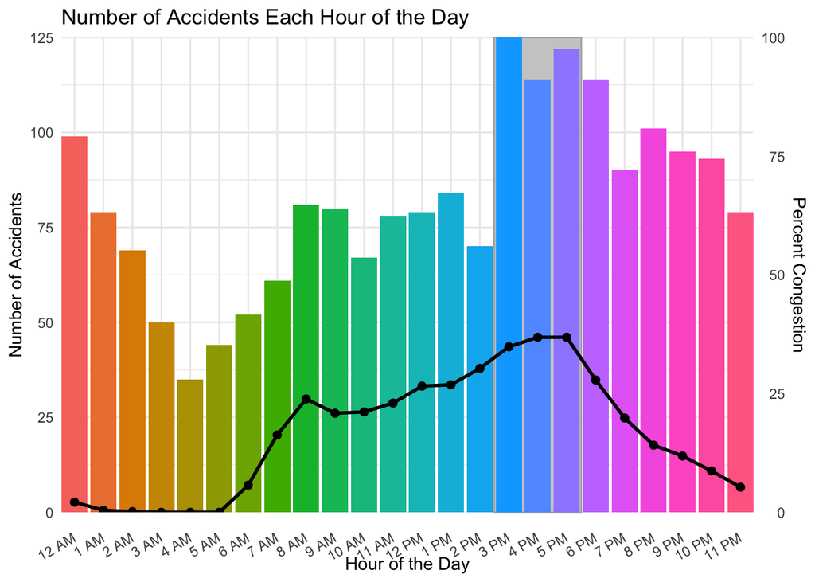

```r
# Values from TomTom were formatted into a csv file for ease of use in our analysis and is provided in the github repo
# Read in congestion data from TomTom
congestion <- read.csv("TomTom_Congestion.csv")

# Format the hours of the day to match our main dataset and summarize the average percent congestion for each hour of the day across a week
cong <- congestion %>%
  mutate(
    hour_of_day_12 = factor(
      sprintf("%d %s",
              (hour_of_day %% 12 == 0) * 12 + (hour_of_day %% 12),
              ifelse(hour_of_day < 12, "AM", "PM")),
      levels = c("12 AM","1 AM","2 AM","3 AM","4 AM","5 AM",
                 "6 AM","7 AM","8 AM","9 AM","10 AM","11 AM",
                 "12 PM","1 PM","2 PM","3 PM","4 PM","5 PM",
                 "6 PM","7 PM","8 PM","9 PM","10 PM","11 PM"),
      ordered = TRUE)) %>%
  select(hour_of_day_12, total)

# Filter a more managable dataset
crash_hourly2 <- crash_clean %>%
  group_by(hour_of_day) %>%
  summarise(n_crashes = n())

crash_hourly2$hour_of_day <- as.numeric(crash_hourly2$hour_of_day)

# Combine datasets
crash_hourly2 <- left_join(crash_hourly2, congestion, by = "hour_of_day")
crash_hourly2 <- crash_hourly2[-25, ]

max_crashes <- max(crash_hourly2$n_crashes, na.rm = TRUE)

# Recreate the hourly crash map with congestion % layered overtop
crash_clean %>%
  filter(!is.na(hour_of_day_12)) %>%
  ggplot(aes(x = hour_of_day_12)) +
  geom_rect(
    aes(xmin = 15.5, xmax = 18.5, ymin = 0, ymax = max_crashes),
    color = "gray70",
    fill = "gray80",
    inherit.aes = FALSE) +
  geom_bar(aes(fill = hour_of_day_12), show.legend = FALSE) +
  geom_line(             ## Congestion line + points
    data = cong,
    aes(x = hour_of_day_12, y = total/100 * max_crashes, group = 1),
    color = "black",
    linewidth = 1) +
  geom_point(
    data = cong,
    aes(x = hour_of_day_12, y = total/100 * max_crashes),
    color = "black",
    size = 2) +
  labs(
    title = "Number of Accidents Each Hour of the Day",
    x = "Hour of the Day",
    y = "Number of Accidents") +
  scale_x_discrete(expand = c(0, 0)) +
  scale_y_continuous(
    expand = c(0, 0),
    sec.axis = sec_axis(~ . / max_crashes * 100,
                        name = "Percent Congestion")) +
  theme_minimal() +
  theme(axis.text.x = element_text(angle = 30, vjust = 0.5, hjust = 1))
```

As expected, the trend in frequency of accidents follows the same trend of congestion on the roads throughout the day with the highest rate of accidents and road congestion during the evening rush hour. Interestingly, in the evening hours from 8pm-1am, there are still a large number of accidents occurring while the congestion rate is relatively low. I would attribute these trends to lack of visibility, either by poor road lighting conditions or lack of running lights on vehicles, and general levels of alertness of drivers at these hours leading to delayed response times to prevent accidents and avoid collisions.

## 4.5 Bike Safety

According to the Bicycle Coalition of Philadelphia, in 2023, “51.1% of bicycle users on the Market St bridge and 85.1% on the JFK Bridge were riding on the sidewalk. This demonstrates a significant need for better infrastructure, especially to travel hubs like the William Gray Amtrak & Regional Rail Station on 30th Street.” ([source](https://storymaps.arcgis.com/stories/f019ae7f7aaf489f9fb828e7038b89d2)).

These two bridges are a main point of travel for commuters who live or work on opposite sides of the Schuylkill river. As a result of unsafe biking routes over this bridge, in March of this year the city began construction on the bridge to install a two-way bike lane with concrete separators and traffic lights. Prior to this construction, no bike lanes were present on the Market Street bridge, requiring cyclists to ride on the sidewalk or in car traffic lanes.

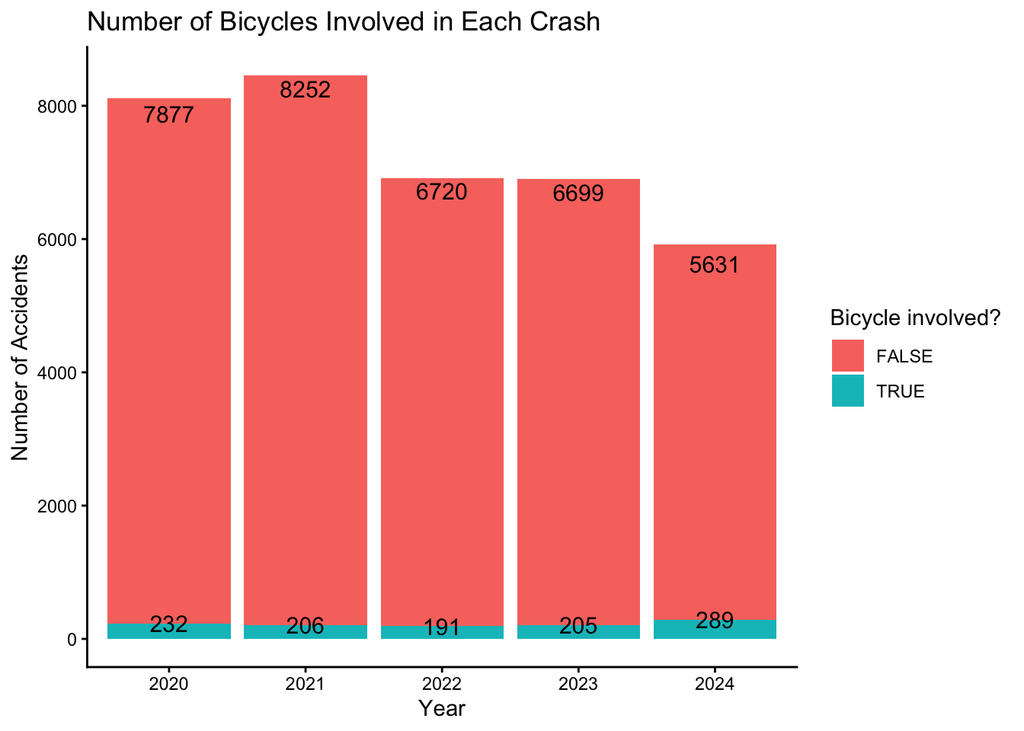

```r
# How many crashes involved bicycles?
ggplot(data = crash_clean, aes(x = crash_year, fill = bicycle_count>0)) +
  geom_bar(position = "stack", stat = "count") +
  labs(title = "Number of Bicycles Involved in Each Crash",
       x = "Year",
       y = "Number of Accidents",
       fill = "Bicycle involved?") +
  theme_classic() +
  geom_text(
    stat = "count",
    aes(label = after_stat(count)), vjust = 0.5, size = 4)
```

## 4.6 Does weather increase the likelihood of an accident?

It is not uncommon to assume that the weather and road conditions can affect the likelihood of an accident. I sought to determine how strong of a factor the weather played in the cause of an accident.

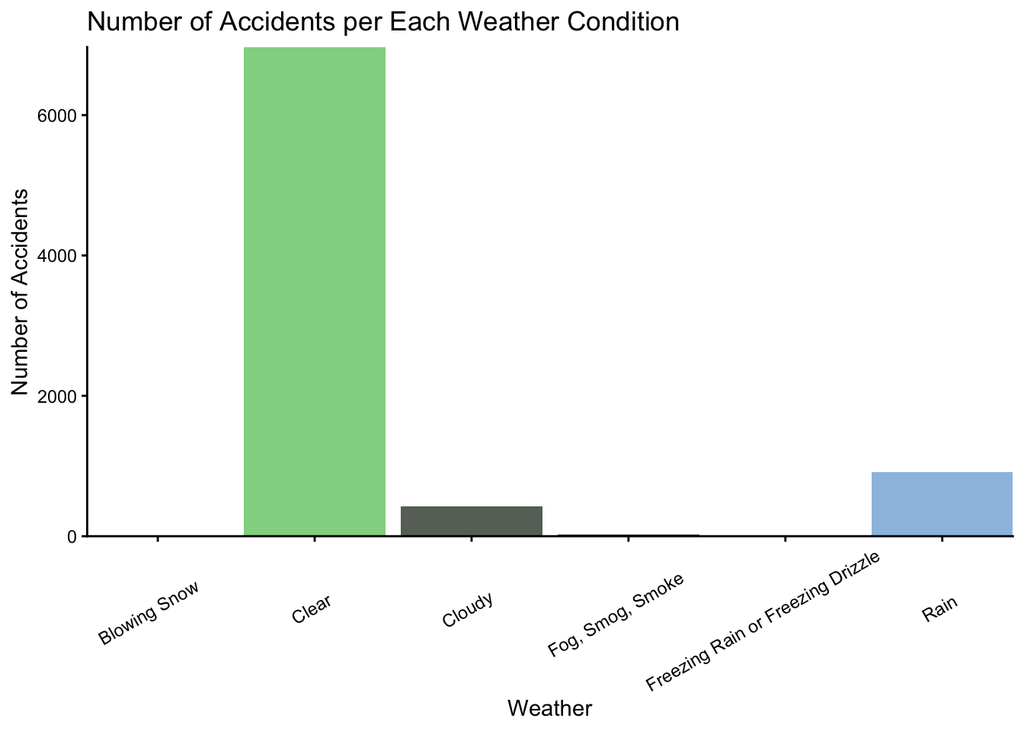

```r
# Create a barplot of the weather conditions at the time of each accident
crash_clean %>%
  filter(!is.na(weather1)) %>% # Filter out data point where weather was not recorded
  ggplot(aes(x = weather1, fill = weather1)) +
  geom_bar(show.legend = FALSE) +
  theme_classic() +
  labs(title = "Number of Accidents per Each Weather Condition",
       x = "Weather",
       y = "Number of Accidents",
       fill = "Weather") +
  scale_fill_manual(values = c("Blowing Snow" = "#CDD0D4", "Clear" = "#90D490", "Fog, Smog, Smoke" = "#1C241C", "Freezing Rain or Freezing Drizzle" = "#2A77D1", "Rain" = "#9DC0E3","Cloudy" = "#687068")) +
  scale_x_discrete(expand = c(0, 0)) +
  scale_y_continuous(expand = c(0, 0)) +
  theme(axis.text.x = element_text(angle = 30, vjust = .6, hjust = 0.6))
```

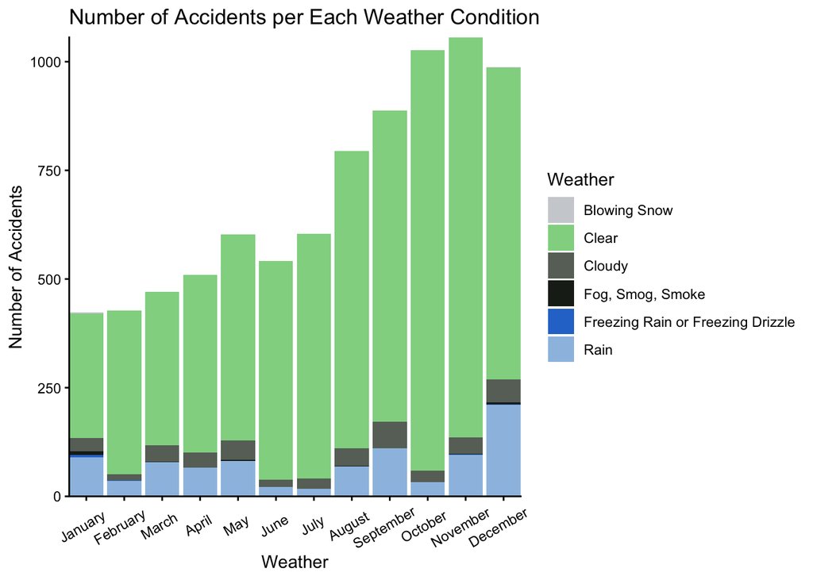

```r
# Are more accidents more likely to be caused by severe weather in the winter months?
winter_weather <- crash_clean %>%
  filter(!is.na(weather1)) %>%
  group_by(crash_month)

# New barplot of the weather conditions present during each crash per month
ggplot(winter_weather, aes(x = crash_month, fill = weather1)) +
  geom_bar() +
  theme_classic() +
  labs(title = "Number of Accidents per Each Weather Condition",
       x = "Weather",
       y = "Number of Accidents",
       fill = "Weather") +
  scale_fill_manual(values = c("Blowing Snow" = "#CDD0D4", "Clear" = "#90D490", "Fog, Smog, Smoke" = "#1C241C", "Freezing Rain or Freezing Drizzle" = "#2A77D1", "Rain" = "#9DC0E3","Cloudy" = "#687068")) +
  scale_x_discrete(expand = c(0, 0)) +
  scale_y_continuous(expand = c(0, 0)) +
  theme(axis.text.x = element_text(angle = 30, vjust = .6, hjust = 0.6))
```

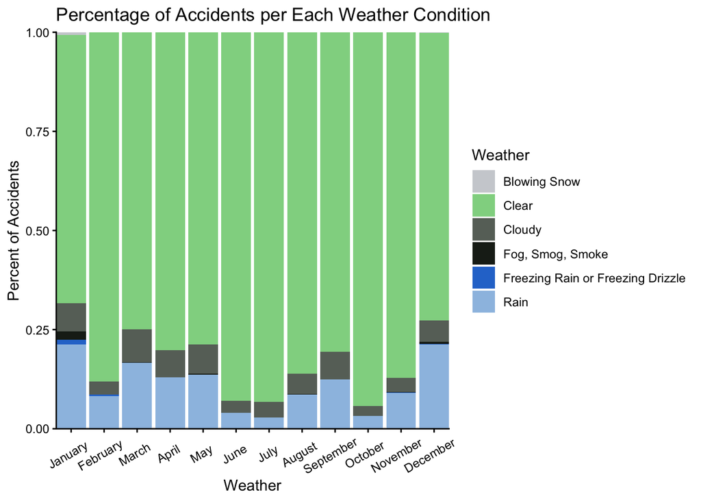

```r
# Replotted to show percentage of each weather condition per month
ggplot(winter_weather, aes(x = crash_month, fill = weather1)) +
  geom_bar(position = "fill") +
  theme_classic() +
  labs(title = "Percentage of Accidents per Each Weather Condition",
       x = "Weather",
       y = "Percent of Accidents",
       fill = "Weather") +
  scale_fill_manual(values = c("Blowing Snow" = "#CDD0D4", "Clear" = "#90D490", "Fog, Smog, Smoke" = "#1C241C", "Freezing Rain or Freezing Drizzle" = "#2A77D1", "Rain" = "#9DC0E3","Cloudy" = "#687068")) +
  scale_x_discrete(expand = c(0, 0)) +
  scale_y_continuous(expand = c(0, 0)) +
  theme(axis.text.x = element_text(angle = 30, vjust = .6, hjust = 0.6))
```

```r
# Statistics to see if weather increases the odds of an accident.
weather_counts <- table(winter_weather$weather1)
weather_counts
```

```
         Blowing Sand, Soil, Dirt                      Blowing Snow
                                0                                 4
                            Clear                            Cloudy
                             6969                               420
                 Fog, Smog, Smoke Freezing Rain or Freezing Drizzle
                               19                                 9
                             Rain
                              908
```

```r
chisq.test(weather_counts)
```

```
    Chi-squared test for given probabilities

data:  weather_counts
X-squared = 33330, df = 6, p-value < 2.2e-16
```

```r
clear_count <- weather_counts["Clear"]
total_crashes <- sum(weather_counts)

other_weather <- setdiff(names(weather_counts), "Clear")

pairwise_results <- lapply(other_weather, function(w) {
  count_w <- weather_counts[w]

  prop.test(
    x = c(count_w, clear_count),
    n = c(total_crashes, total_crashes),
    alternative = "greater",      # Is weather W MORE likely than clear?
    correct = TRUE)})

names(pairwise_results) <- other_weather
pairwise_results
```

```
$`Blowing Sand, Soil, Dirt`

    2-sample test for equality of proportions with continuity correction

data:  c(count_w, clear_count) out of c(total_crashes, total_crashes)
X-squared = 11978, df = 1, p-value = 1
alternative hypothesis: greater
95 percent confidence interval:
 -0.843497  1.000000
sample estimates:
   prop 1    prop 2
0.0000000 0.8367151


$`Blowing Snow`

    2-sample test for equality of proportions with continuity correction

data:  c(count_w, clear_count) out of c(total_crashes, total_crashes)
X-squared = 11962, df = 1, p-value = 1
alternative hypothesis: greater
95 percent confidence interval:
 -0.8430284  1.0000000
sample estimates:
      prop 1       prop 2
0.0004802497 0.8367150918


$Cloudy

    2-sample test for equality of proportions with continuity correction

data:  c(count_w, clear_count) out of c(total_crashes, total_crashes)
X-squared = 10428, df = 1, p-value = 1
alternative hypothesis: greater
95 percent confidence interval:
 -0.7941506  1.0000000
sample estimates:
    prop 1     prop 2
0.05042622 0.83671509
```

[output cut: 27 more lines]

```
0.001080562 0.836715092


$Rain

    2-sample test for equality of proportions with continuity correction

data:  c(count_w, clear_count) out of c(total_crashes, total_crashes)
X-squared = 8844.3, df = 1, p-value = 1
alternative hypothesis: greater
95 percent confidence interval:
 -0.7365323  1.0000000
sample estimates:
   prop 1    prop 2
0.1090167 0.8367151
```

```r
results_df <- data.frame(
  weather = other_weather,
  count = as.numeric(weather_counts[other_weather]),
  proportion = as.numeric(weather_counts[other_weather] / total_crashes),
  p_value = sapply(pairwise_results, function(p) p$p.value))

results_df
```

```
                                                            weather count
Blowing Sand, Soil, Dirt                   Blowing Sand, Soil, Dirt     0
Blowing Snow                                           Blowing Snow     4
Cloudy                                                       Cloudy   420
Fog, Smog, Smoke                                   Fog, Smog, Smoke    19
Freezing Rain or Freezing Drizzle Freezing Rain or Freezing Drizzle     9
Rain                                                           Rain   908
                                    proportion p_value
Blowing Sand, Soil, Dirt          0.0000000000       1
Blowing Snow                      0.0004802497       1
Cloudy                            0.0504262216       1
Fog, Smog, Smoke                  0.0022811862       1
Freezing Rain or Freezing Drizzle 0.0010805619       1
Rain                              0.1090166887       1
```

Majority of accidents occurred during “clear” weather conditions, with “rain” being the second highest category. There is no significant correlation between non-clear weather conditions and the likelihood of an accident occurring in Philadelphia.

## 4.7 Demographics of Drivers Most Frequently Involved in Accidents

I also wanted to investigate whether the claim that newer/younger drivers are more frequently involved in accidents. This dataset took note of the drivers age if they fell into one the following categories: 16yrs old, 17yrs old, 18yrs old, 19yrs old, 20yrs old, 50-64yrs old, 65-74yrs old, or 75+. From here I can analyze whether younger or older drivers are more likely to cause an accident.

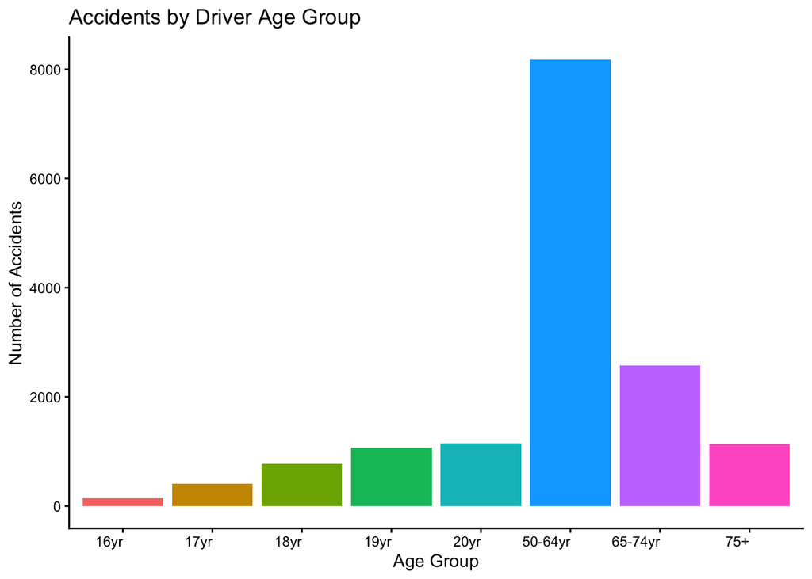

```r
# Select columns of interest from the main dataset and set 1 = TRUE for causing an accident
driver_summary_long <- crash_data %>%
  select(driver_16yr, driver_17yr, driver_18yr, driver_19yr, driver_20yr,
         driver_50_64yr, driver_65_74yr, driver_75plus) %>%
  pivot_longer(everything(), names_to = "age_group", values_to = "value") %>%
  summarize(count = sum(value == 1, na.rm = TRUE), .by = age_group)

# Create a barplot of the age of drivers who caused an accident
ggplot(data = driver_summary_long, aes(x = age_group, y = count, fill = age_group)) +
  geom_col(show.legend = FALSE) +
  labs(title = "Accidents by Driver Age Group",
       x = "Age Group",
       y = "Number of Accidents",
       fill = "Age Group") +
  scale_x_discrete(labels = c("driver_16yr" = "16yr",
                      "driver_17yr" = "17yr",
                      "driver_18yr" = "18yr",
                      "driver_19yr" = "19yr",
                      "driver_20yr" = "20yr",
                      "driver_50_64yr" = "50-64yr",
                      "driver_65_74yr" = "65-74yr",
                      "driver_75plus" = "75+")) +
  theme_classic() +
  theme(axis.text.x = element_text(hjust = 1))
```

[figure not shown]

```r
# Group drivers into bins below 20 and over 50 years old
driver_groups <- crash_data %>%
  summarise(
    a_20_under = sum(driver_16yr == 1 |
                         driver_17yr == 1 |
                         driver_18yr == 1 |
                         driver_19yr == 1 |
                         driver_20yr == 1, na.rm = TRUE),

    a_50_plus = sum(driver_50_64yr == 1 |
                        driver_65_74yr == 1 |
                        driver_75plus == 1, na.rm = TRUE)
  ) %>%
  tidyr::pivot_longer(cols = everything(),
                      names_to = "age_group",
                      values_to = "count")

# Replot the graph with the age categories
ggplot(driver_groups, aes(x = age_group, y = count, fill = age_group)) +
  geom_col(show.legend = FALSE) +
  labs(title = "Accidents by Age Group",
       x = "Age Group",
       y = "Number of Accidents",
       fill = "Age Group") +
  scale_x_discrete(labels = c("a_20_under" = ">20yrs",
                      "a_50_plus" = "<50")) +
  theme_classic() +
  theme(axis.text.x = element_text(angle = 20, hjust = 1))
```

Strikingly, individuals who are 50-64 years old are very often the cause of accidents compared to any other age group. Those aged 50-64 years old are three times more likely to be the cause of an accident compared to the second highest demographic, 65-74 years old. Importantly of note is to factor into account that the 50-64 year old age range comprises 15 years compared to the grouped bin of 5 years for younger drivers.

We can normalize these rates to get a better indication of how age correlates to the likelihood of an accident.

```r
# Group drivers into bins below 20, 50-64, 65-74, and 75+ years old
driver_groups2 <- crash_data %>%
  summarise(
    a_20_under = sum(driver_16yr == 1 |
                         driver_17yr == 1 |
                         driver_18yr == 1 |
                         driver_19yr == 1 |
                         driver_20yr == 1, na.rm = TRUE),

    a_50_64 = sum(driver_50_64yr == 1,
                  na.rm = TRUE),
    a_65_74 = sum(driver_65_74yr == 1,
                  na.rm = TRUE),
    a_75 = sum(driver_75plus == 1,
                  na.rm = TRUE)) %>%
  tidyr::pivot_longer(cols = everything(),
                      names_to = "age_group",
                      values_to = "count")

# Add a row of how many years are in each bin, calcuate the number of accidents/years in group
age_rates <- driver_groups2 %>%
  mutate(years_in_group = case_when(
      age_group == "a_20_under" ~ 5,
      age_group == "a_50_64" ~ 15,
      age_group == "a_65_74" ~ 15,
      age_group == "a_75" ~ 30, # Lets say that this category ranges from 75-105 years old since there is no true age cap to this category
      TRUE ~ NA_real_),
    accidents_per_age_year = count / years_in_group)

age_rates
```

```
# A tibble: 4 × 4
  age_group  count years_in_group accidents_per_age_year
  <chr>      <int>          <dbl>                  <dbl>
1 a_20_under  3459              5                  692.
2 a_50_64     8178             15                  545.
3 a_65_74     2575             15                  172.
4 a_75        1143             30                   38.1
```

Performing our analysis by looking at the rate of accidents per age and adjusted for the variety in years which span our group, we observe that there is in fact a higher rate of accidents caused by younger drivers than any of the older groups.

## 4.8 Visualizing Geo-spatial Data

All roads in Philadelphia are not created equal and some are much safer than others due to lower speed limits, traffic lights instead of stop signs, visibility, and quantity of drivers on that road. I wished to visualize each recorded accident from 2020-2024 on a map of Philadelphia to identify areas with a higher rate of accidents. To complete this analysis we will need to acquire .geojson and shapefile data from this time frame ([source](https://metadata.phila.gov/#home/datasetdetails/5543865420583086178c4eba/representationdetails/68ae0feae3c7df02c27bfe7b/)).

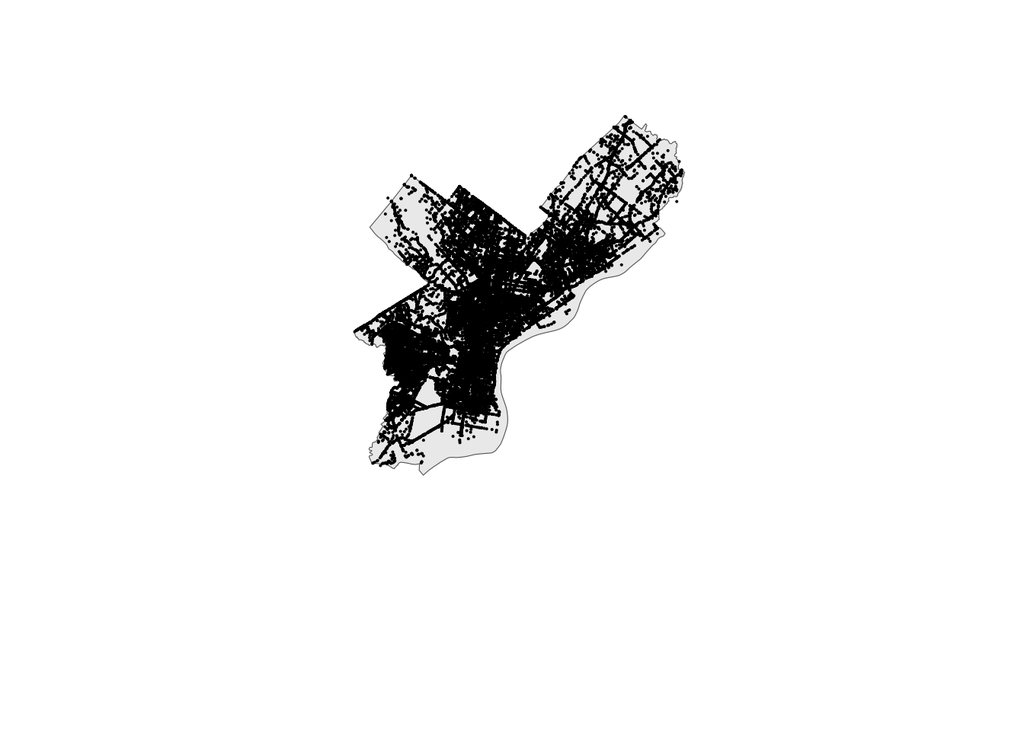

```r
#Lets read in the .geojson file which will give us the boundaries for a map
Philly_sf <- read_sf("City_Limits.geojson")

#Acquire and read in the shapefile of Philly neighborhood boundaries
neighborhoods_url <- "https://raw.githubusercontent.com/opendataphilly/open-geo-data/master/philadelphia-neighborhoods/philadelphia-neighborhoods.geojson"
philly_neighborhoods <- sf::st_read(neighborhoods_url)
# Get all local streets + main roads
philly_streets <- opq(bbox = c(-75.3, 39.7, -74.95, 40.2)) %>%
  add_osm_feature(key = "highway",
                  value = c("motorway", "primary", "secondary", "tertiary",
                            "residential", "unclassified", "service")) %>%
  osmdata_sf()

# By plotting the longitude and latitude of each crash, we can visualize where these crashes occurred on a map of the city.
ggplot() +
  geom_sf(data = Philly_sf, fill = "grey", alpha = 0.3) +
  geom_point(
    data = crash_clean,
    aes(x = dec_longitude, y = dec_latitude),
    size = .05) +
  theme_void() +
  coord_sf(xlim = c(-75.3, -74.95), ylim = c(39.7, 40.2))
```

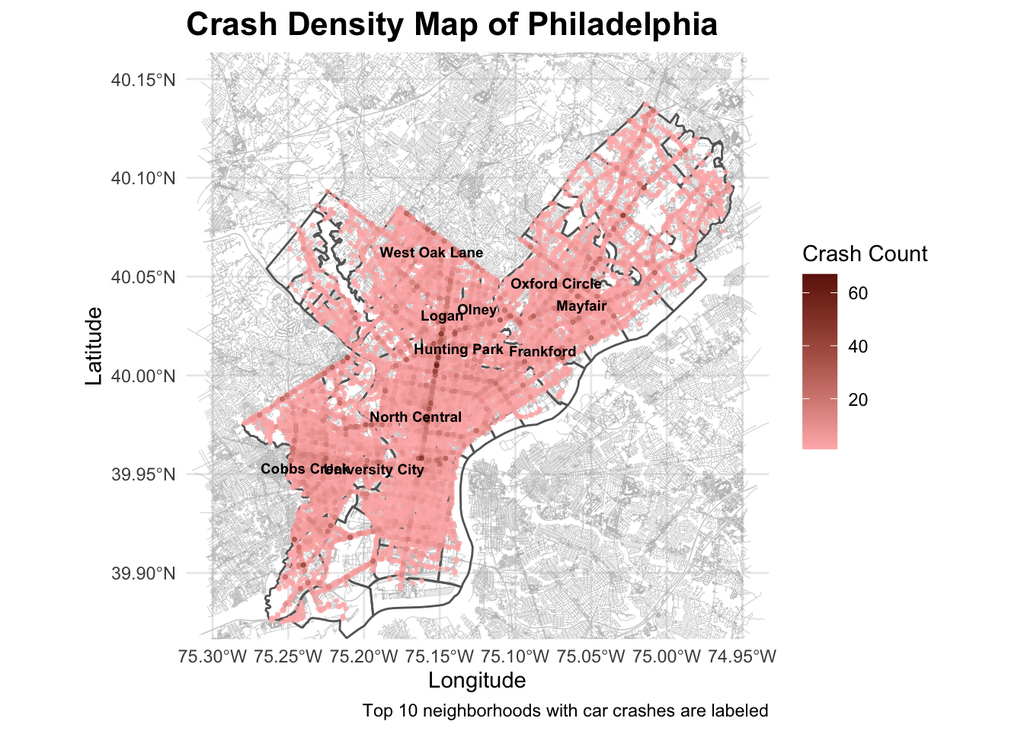

```r
# Plotting this way gives us a single data point for each crash, which is messy and doesn't allow us to identify regions which are more likely to have a crash occur.

# Cluster crashes by location
crash_cluster <- crash_clean %>%
  count(dec_longitude, dec_latitude) %>%
  arrange(n)  # low → high count so high plot last (on top)

# Convert crash points to sf and adjust geometry
crash_sf <- st_as_sf(crash_clean, coords = c("dec_longitude", "dec_latitude"), crs = 4326)
philly_neighborhoods <- st_make_valid(philly_neighborhoods)

# Combine files
crashes_by_nhood <- st_join(crash_sf, philly_neighborhoods, join = st_within)

# Filter the top 10 neighborhoods with accidents
top10_nhoods <- crashes_by_nhood %>%
  st_drop_geometry() %>%
  group_by(NEIGHBORHOOD = NAME) %>%
  summarize(crash_count = n()) %>%
  arrange(desc(crash_count)) %>%
  slice(1:10)

# Filter neighborhoods to only those top 10 for labeling
nhoods_to_label <- philly_neighborhoods %>%
  filter(NAME %in% top10_nhoods$NEIGHBORHOOD)

# Prepare crash density layer
crash_density <- crash_clean %>%
  mutate(long_bin = round(dec_longitude, 3),
         lat_bin = round(dec_latitude, 3)) %>%
  count(long_bin, lat_bin) %>%
  arrange(n)  # smallest first, biggest plotted last (on top!)

ggplot() +
  geom_sf(data = philly_streets$osm_lines, color = "grey70", size = 0.2, alpha = 0.5) +
  geom_sf(data = philly_neighborhoods, fill = NA, color = "grey40", linewidth = 0.5) +
  geom_point(
    data = crash_density,
    aes(x = long_bin, y = lat_bin, color = n),
    alpha = 0.7, size = .6) +
  scale_color_gradient(low = "#FFB8B8", high = "#6F1B0B", name = "Crash Count") +
  geom_sf_text(
    data = nhoods_to_label,
    aes(label = MAPNAME),
    size = 2.5,
    fontface = "bold",
    color = "black") +
  labs(
    title = "Crash Density Map of Philadelphia",
    caption = "Top 10 neighborhoods with car crashes are labeled",
    x = "Longitude",
    y = "Latitude") +
  theme_minimal() +
  coord_sf(xlim = c(-75.3, -74.95), ylim = c(39.88, 40.15)) +
  theme(
    legend.position = "right",
    plot.title = element_text(size = 16, face = "bold"),
    plot.subtitle = element_text(size = 12))
```

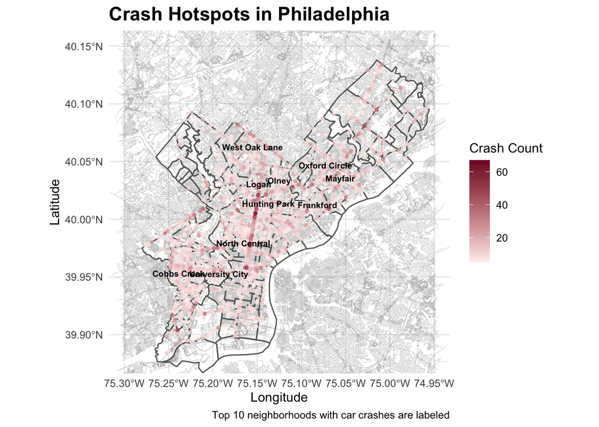

```r
# This is still too many data points to view all at once. Lets filter the locations where there were more than 4 accidents recorded
crash_hotspots <- crash_density %>%
  dplyr::filter(n > 4)

ggplot() +
  geom_sf(data = philly_streets$osm_lines, color = "grey70", size = 0.2, alpha = 0.5) +
  geom_sf(data = philly_neighborhoods, fill = NA, color = "grey40", linewidth = 0.5) +
  geom_point(
    data = crash_hotspots,
    aes(x = long_bin, y = lat_bin, color = n),
    alpha = 0.7, size = 1) +
  scale_color_gradient(low = "#FFF0F0", high = "#800f2f", name = "Crash Count") +
  geom_sf_text(
    data = nhoods_to_label,
    aes(label = MAPNAME),
    size = 2.5,
    fontface = "bold",
    color = "black") +
  labs(
    title = "Crash Hotspots in Philadelphia",
    caption = "Top 10 neighborhoods with car crashes are labeled",
    x = "Longitude",
    y = "Latitude") +
  theme_minimal() +
  coord_sf(xlim = c(-75.3, -74.95), ylim = c(39.88, 40.15)) +
  theme(
    legend.position = "right",
    plot.title = element_text(size = 16, face = "bold"),
    plot.subtitle = element_text(size = 12))
```

### 4.8.1 Interactive Choropleth map

```r
crash_points <- st_as_sf(
  crash_cluster,
  coords = c("dec_longitude", "dec_latitude"),
  crs = 4326,   # WGS84 (latitude/longitude)
  remove = FALSE)

crash_with_neighborhood <- st_join(crash_points, philly_neighborhoods["MAPNAME"], left = FALSE)

neighborhood_crash_counts <- crash_with_neighborhood %>%
  group_by(MAPNAME) %>%
  summarize(total_crashes = sum(n))

philly_neighborhoods_with_counts <- philly_neighborhoods %>%
  st_join(neighborhood_crash_counts) %>%
  mutate(total_crashes = replace_na(total_crashes, 0))

# Pop-up message
pu_message <- paste0(philly_neighborhoods_with_counts$MAPNAME.x,
                     "<br>Number of crashes: ",       #<br> forces new line
                     #Use round function to round continuous poverty rate to one decimal point
                     round(philly_neighborhoods_with_counts$total_crashes, 1))

# Set up palette colors and set bins
pal_fun <- leaflet::colorBin(palette = brewer.pal(9, "Purples")[c(1:8)],
                             bins = c(0, 180, 360, 540, 720, 900, 1080, 1260), reverse = FALSE,
                             NULL)

# Plot your interactive map!
leaflet(philly_neighborhoods_with_counts) %>%
  addPolygons(stroke = TRUE, # remove polygon borders
              color = "black",
              weight = 0.5,
              fillColor = ~ pal_fun(total_crashes),
              fillOpacity = 1, smoothFactor = 0.5, # increase opacity and resolution
              popup = pu_message) |>
  addLegend("bottomright",
            pal = pal_fun,
            values = ~ total_crashes,  # variable to pass to palette function
            title = 'Crashes Per <br>Neighborhood',
            opacity = 1) |> # legend opacity (1 = completely opaque)
  addScaleBar()
```

[interactive chart not shown]

### 4.8.2 Accidents per Neighborhood in 2020 vs 2024

I was curious to see if the rates of car accidents in certain neighborhood increased or decreased from 2020 to 2024.

```r
# Convert crash data to sf points
crashes_sf <- crash_clean %>%
  filter(!is.na(dec_longitude), !is.na(dec_latitude)) %>%
  st_as_sf(coords = c("dec_longitude", "dec_latitude"), crs = 4326)

crashes_with_neighborhood <- st_join(crashes_sf, philly_neighborhoods, left = FALSE)

crash_counts <- crashes_with_neighborhood %>%
  filter(crash_year %in% c(2020, 2024)) %>%
  st_drop_geometry() %>%
  count(MAPNAME, crash_year) %>%
  tidyr::pivot_wider(names_from = crash_year, values_from = n,
                     names_prefix = "year_", values_fill = 0)

# Calculate the percent change in number of accidents for 2020 vs 2024
crash_change <- crash_counts %>%
  mutate(
    percent_change = ifelse(year_2020 == 0, NA,
                            (year_2024 - year_2020) / year_2020 * 100))

neigh_map <- philly_neighborhoods %>%
  left_join(crash_change, by = "MAPNAME")

# Pop-up message
pu_message <- paste0(neigh_map$MAPNAME,
                     "<br>Percent change: ",       #<br> forces new line
                     #Use round function to round continuous poverty rate to one decimal point
                     round(neigh_map$percent_change, 1))

# Set up palette colors and set bins
n <- 256
n1 <- max(2, round(0.25 * n))    # green -> white
n2 <- max(2, n - n1)
pal_colors <- c(
  colorRampPalette(c("#3AA12F", "#FFFFFF"))(n1), # decrease in rate of accidents is green
  colorRampPalette(c("#FFFFFF", "#A12F2F"))(n2)) # increase in rate of accidents is red

percent <- colorNumeric(palette = pal_colors, domain = c(-100, 300), na.color = "#BEBEBE")

# Plot the interactive map!
leaflet(neigh_map) %>%
  addPolygons(stroke = TRUE, # remove polygon borders
              color = "black",
              weight = 0.5,
              fillColor = ~ percent(percent_change),
              fillOpacity = 1, smoothFactor = 0.5, # increase opacity and resolution
              popup = pu_message) |>
  addLegend("bottomright",
            pal = percent,
            values = ~ percent_change,  # variable to pass to palette function
            title = 'Percent Change <br>Per Neighborhood',
            opacity = 1) |> # legend opacity (1 = completely opaque)
  addScaleBar()
```

[interactive chart not shown]

Many neighborhoods in Philadelphia have a negative change in the number of accidents (denoted by green areas) from 2020 to 2024, indicating fewer accidents over time. This data is encouraging and suggests that efforts are successfully being made by both the city and drivers on the road to reduce the number of car accidents in Philly.

### 4.8.3 Accidents Involving Bicycles or Pedestrians

As Philadelphia is an extremely walkable/bikeable city, I wanted to determine if there were specific areas that were an increased hazard for cyclists or pedestrians.

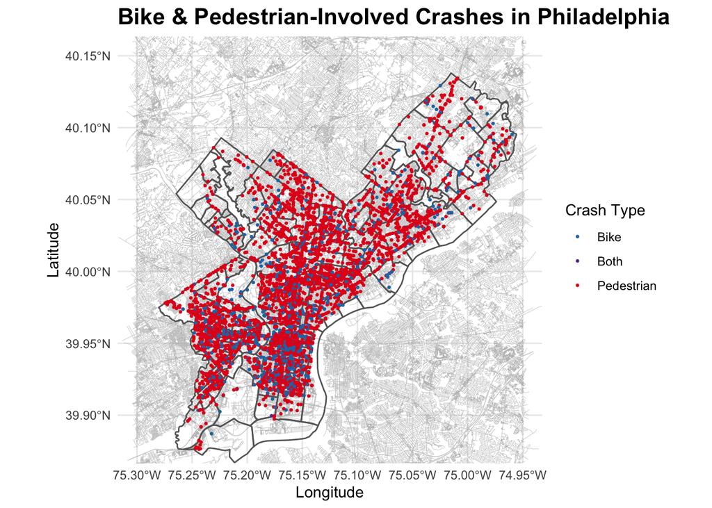

```r
# Filter the accidents involving a bike or pedestrian into a new df and label "crash_type"
bike_ped_crashes <- crash_clean %>%
  mutate(crash_type = case_when(
    bicycle == 1 & pedestrian == 1 ~ "Both",
    bicycle == 1 ~ "Bike",
    pedestrian == 1 ~ "Pedestrian"
  )) %>%
  filter(!is.na(crash_type))

# Plot each accident on our geospatial map of Philadelphia
ggplot() +
  geom_sf(data = philly_streets$osm_lines, color = "grey70", size = 0.2, alpha = 0.5) +
  geom_sf(data = philly_neighborhoods, fill = NA, color = "grey40", linewidth = 0.5) +
  geom_point(
    data = bike_ped_crashes,
    aes(x = dec_longitude, y = dec_latitude, color = crash_type),
    alpha = 1, size = 0.5) +
  scale_color_manual(
    values = c(
      "Bike" = "#1f78b4",
      "Pedestrian" = "#e31a1c",
      "Both" = "#6a3d9a"),
    name = "Crash Type") +
  labs(
    title = "Bike & Pedestrian-Involved Crashes in Philadelphia",
    x = "Longitude",
    y = "Latitude") +
  theme_minimal() +
  coord_sf(xlim = c(-75.3, -74.95), ylim = c(39.88, 40.15)) +
  theme(
    legend.position = "right",
    plot.title = element_text(size = 16, face = "bold"))
```

There do appear to be trends in specific areas where accidents involving bicycles or pedestrians are more likely. For example, there are many accidents involving pedestrians in Center City and along Broad Street. Additionally, accidents involving cyclists are recorded most frequently in West Philadelphia neighborhoods, Central Philadelphia, and South Philadelphia.

# 5 Conclusion

By analyzing car accident data in Philadelphia, interesting trends are observed.

To start off, the number of total accidents in the city have decreased over the past five years, unfortunately however, the number of fatalities as a rate of these accidents remains relatively unchanged (Section 4.1).

Examining when the most accidents occur provided interesting results. It does not appear that a particular month sees the highest frequency of accidents, this changes from year to year. However, the most accidents occur on Fridays. Statistical analysis determined that accidents on Friday are more likely than any other day of the week outside of Saturday. Section 4.2

When examining when accidents are most likely to occur, it is no surprise that the highest frequency of accidents occur during the evening rush hour times (3-6pm) Section 4.3 . By layering on the percentage of road congestion throughout the day, the conclusion that a higher number of cars on the road is contributing to the increased rate of accidents, is even more clear Section 4.4 .

When examining the counts of age groups responsible for causing an accident, the 50-64 year old demographic stands out as the primary group as the catalyst for accidents. However, when this data is scaled correctly to account for the wide age range of 15 years in this category, newer drivers under the age of 20 are most often the cause of an accident. I think additional road training is necessary for individuals before obtaining a license in the state of Pennsylvania. As a previous New Jersey resident, we were required to have 6 hours of supervised driving instruction from a licensed driving school. I believe that this hands-on instruction in addition to supervised parental driving with a permit allows for safer, more confident drivers who are aware of all traffic laws and how to handle a variety of driving scenarios Section 4.7 .

For many individuals in Philadelphia, biking is a more common mode of transportation than driving. Over the past five years, the number of accidents involving bicycles remains relatively unchanged Section 4.5 . Additionally, certain regions of Philadelphia see a higher rate of accidents involving bicycles, such as West Philadelphia neighborhoods, Central Philadelphia, and South Philadelphia. Efforts across the city to install more protected bike lanes to encourage cyclists to stay out of lanes designed for cars and have additional protections while on the road. While I think these efforts will be effective, by geographically mapping locations with a high frequency of bike-involving accidents, I have identified additional regions which would benefit from increased measures to ensure cyclist safety Section 4.8.3 .

When plotting each accident over a map of Philadelphia, specific streets and neighborhoods stand out as areas with a high frequency of accidents. Many accidents occur along Broad street specifically in Hunting Park, Logan, and North Central Philadelphia. As a result, targeted efforts to increase road safety in these areas should be considered a top priority. By lowering the speed limit, replacing stop signs with traffic lights, and increasing visibility in this area, we can hopefully lower the rate of accidents Section 4.8 & Section 4.8.1 . On a positive note, the rates of accidents in each neighborhood has decreased across the board in most areas, indicating that previous steps to improve safety in these regions were successful Section 4.8.2 .

In conclusion, from analysis of this dataset, I have been able to identify specific times, conditions, and locations which increase the likelihood of accidents to happen. Efforts to modify infrastructure, increase visibility, and implementing traffic slowing measures such as speed bumps and traffic lights instead of stop signs would improve road safety for all drivers, cyclists, and pedestrians.

# 6 References

- OpenDataPhilly
  - Car Crash dataset - [Link](https://opendataphilly.org/datasets/crashes/)
  - City Limits for geospatial maps - [Link](https://opendataphilly.org/datasets/city-limits/), [Link](https://metadata.phila.gov/#home/datasetdetails/5543865420583086178c4eba/representationdetails/68ae0feae3c7df02c27bfe7b/)
- TomTom - [Link](https://www.tomtom.com/traffic-index/philadelphia-pa-traffic/)
- Public Use Microdata Areas (PUMAs) - [Link](https://www.census.gov/programs-surveys/geography/guidance/geo-areas/pumas.html)
- Bicycle Coalition of Philadelphia - [Link](https://storymaps.arcgis.com/stories/f019ae7f7aaf489f9fb828e7038b89d2)
- World Population Review - [Link](https://worldpopulationreview.com/us-cities/pennsylvania/philadelphia)